# 1. Order of faces using ISOMAP

The objective of this question is to reproduce the ISOMAP algorithm results that we have seen discussed in lecture as an exercise. The file `isomap.mat` (or `isomap.dat`) contains 698 images, corresponding to different poses of the same face. Each image is given as a 64 x 64 luminosity map, hence represented as a vector in $\mathbb{R}^{4096}$. This vector is stored as a row in the file. [This is one of the datasets used in the original paper for ISOMAP, J.B. Tenenbaum, V. de Silva, and J.C. Langford, Science 290 (2000) 2319-2323.]

## a. Visualize similarity graph

Choose the Euclidean distance between images (i.e., in this case a distance in $\mathbb{R}^{4096}$). Construct a similarity graph with vertices corresponding to the images, and tune the threshold $\epsilon$ so that each node has at least 100 neighbors. Visualize the similarity graph (e.g., plot the adjacency matrix, or visualize the graph and illustrate a few images corresponds to nodes at different parts of the graph; you can be a bit creative here).

The image below depicts a graph formed from the weighted adjacency matrix whose entries are Euclidean the distances between connected nodes. Nodes are connected if the distance between them is less than ~22.414 (i.e. $\epsilon \approx 22.414$).

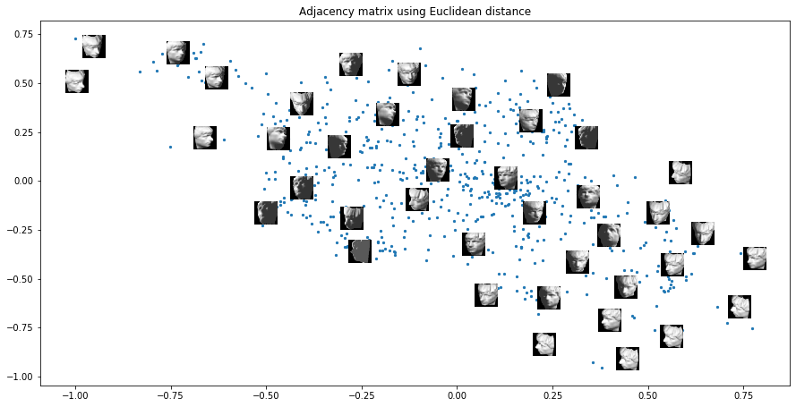

Node/image positions are purely relative, and are set by `networkx`'s `spring_layout` function.

## b. Apply ISOMAP for 2-D embedding

Implement the ISOMAP algorithm and apply it to this graph to obtain a $d$ = 2-dimensional embedding. Present a plot of this embedding. Find three points that are "close" to each other in the embedding space, and show what they look like. Do you see any visual similarity among them?

The image below plots the 2-D embedding of the original images using ISOMAP. I have specifically circled three points that are close to each other. It appears that they are facing roughly the same direction.

Looking at other groups of faces shows that points near each other elsewhere in the plot are generally facing the same direction as well.

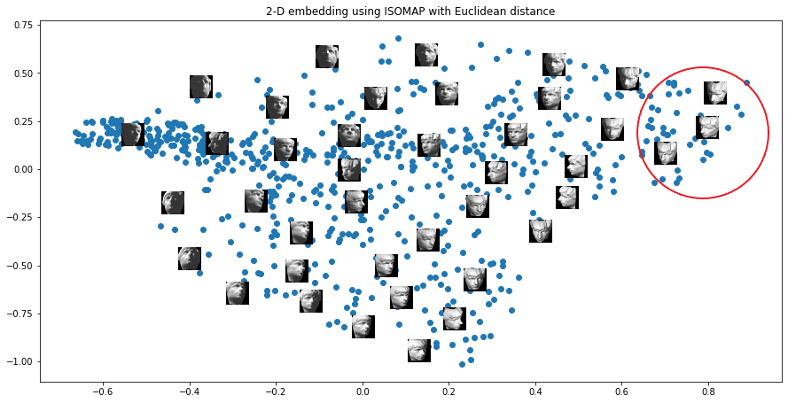

## c. Manhattan distance

Now choose $\ell_1$ distance (or Manhattan distance) between images (recall the defnition from "Clustering" lecture). Repeat the steps above. Again construct a similarity graph with vertices corresponding to the images, and tune the threshold $\epsilon$ so that each node has at least 100 neighbors. Implement the ISOMAP algorithm and apply it to this graph to obtain a $d$ = 2-dimensional embedding. Present a plot of this embedding. Do you see any difference by choosing a different similarity measure?

The image below depicts a graph formed from the weighted adjacency matrix whose entries are the **Manhattan** distances between connected nodes. Nodes are connected if the distance between them is less than ~1011 (i.e. $\epsilon \approx 1011$).

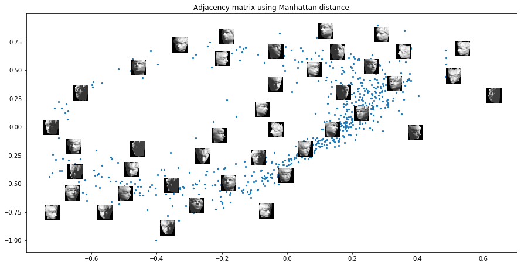

The image **below** plots the 2-D embedding of the original images using ISOMAP and Manhattan distance. I have specifically circled three points that are close to each other. It appears that they are facing roughly the same direction, just as I saw with the plot from 1b.

Looking at other groups of faces shows that points near each other elsewhere in the plot are generally facing the same direction as well.

There does not appear to be a real difference between the embeddings generated using Manhattan distance vs. Euclidean distance, except that the range of values in the Manhattan distance embedding are of a larger magnitude. The plot below looks almost exactly like the plot generated using Euclidean distance - but mirrored over the x- and y-axes. The **relative positions** of faces remain mostly the same, however.

The presence of certain clusters of faces also remains the same, such as the tight cluster on the lower-right side of this plot, which is present in the upper-left side of plot of the Euclidean distance embedding.

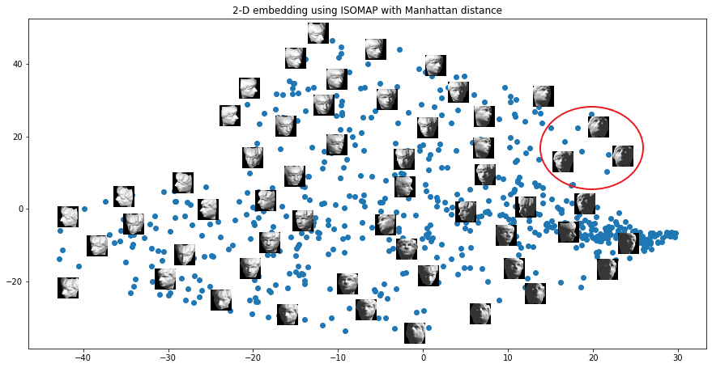

# 2. Density estimation

The data set `n90pol.csv` contains information on 90 university students who participated in a psychological experiment designed to look for relationships between the size of different regions of the brain and political views. The variables `amygdala` and `acc` indicate the volume of two particular brain regions known to be involved in emotions and decision-making, the amygdala and the anterior cingulate cortex; more exactly, these are residuals from the predicted volume, after adjusting for height, sex, and similar body-type variables. The variable orientation gives the students' locations on a five-point scale from 1 (very conservative) to 5 (very liberal).

## a. 2-D histograms

Form 2-dimensional histogram for the pairs of variables (`amygdala`, `acc`). Decide on a suitable number of bins so you can see the shape of the distribution clearly.

A 2-D histogram with 15 bins is shown below. I chose 15 after experimenting with a range of bin numbers and comparing the 2-D histogram to both 1-D histograms to ensure that the shape of each variable's distribution was not obscured.

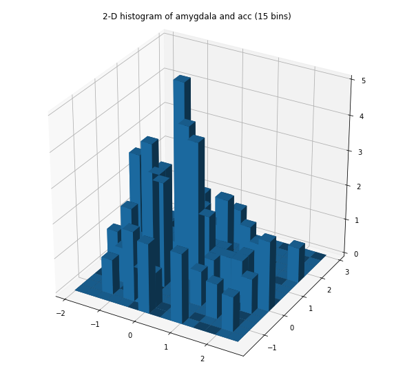

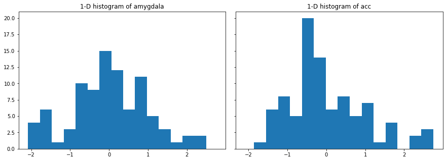

## b. Kernel density estimation

Now implement kernel-density-estimation (KDE) to estimate the 2-dimensional with a two-dimensional density function of `(amygdala, acc)`. Use a simple multi-dimensional Gaussian kernel, for

$$ x = \begin{bmatrix} x_1 \\ x_2 \end{bmatrix} \in \mathbb{R}^2 $$

where $x_1$ and $x_2$ are two dimensions respectively

$$ K(x) = \frac{1}{\sqrt{2\pi}}e^{-\frac{(x_1^2 + x_2^2)}{2}} . $$

Recall in this case, the kernel density estimator (KDE) for a density is given by

$$ p(x) = \frac{1}{m} \sum_{i=1}^{m} \frac{1}{h}K \left( \frac{x_i - x}{h} \right), $$

where $x_i$ are two-dimensional vectors, $h > 0$ is the kernel bandwidth. Set an appropriate $h$ so you can see the shape of the distribution clearly. Plot of contour plot (like the ones in slides) for your estimated density.

The contour plots were generated using standardized data.

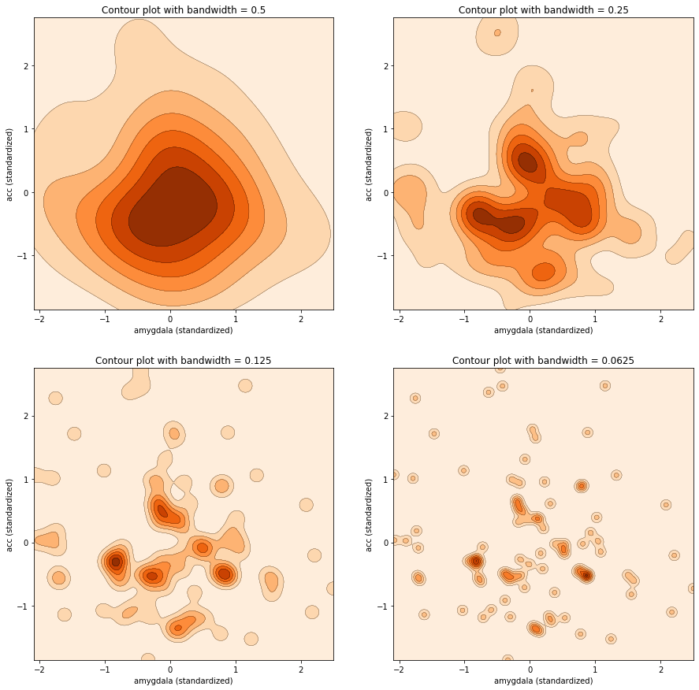

## c. Conditional distribution plots

Plot the condition distribution of the volume of the `amygdala` as a function of political `orientation`: $p(amygdala|orientation = a), a = 1,\dots,5$. Do the same for the volume of the `acc`. Plot $p(acc|orientation = a), a = 1,\dots,5$. You may either use histogram or KDE to achieve the goal.

The plots below (generated using `seaborn`) show the density plots for each variable/orientation combination. This plot shows clearly that the distribution of each variable is different by orientation.

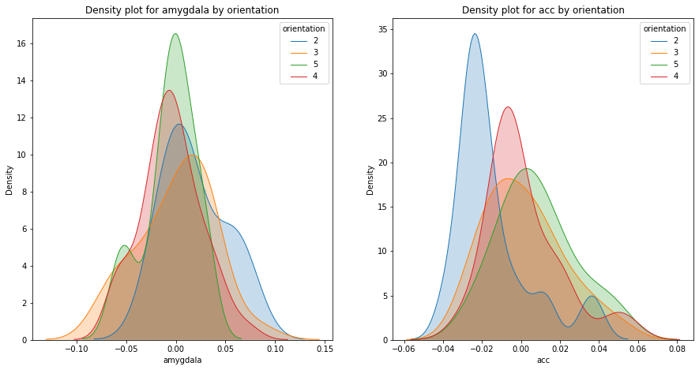